# Basic Forum Stats

Quantify users vs registrations with “Student” role (access_group_id=4).

```
## SELECT count(1) registered, sum(last_access_time >0) accessed FROM vpodata_aiplangen.users WHERE access_group_id=4
```

| id | registered | accessed |
| --- | --- | --- |
| aiplan | 26470 | 15342 |
| astro | 34925 | 20175 |
| crit | 67711 | 34437 |
| edc | 38944 | 21609 |
| equine | 23410 | 18921 |
| intro | 87186 | 51849 |

Proportion of show/no-show.

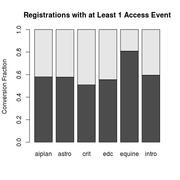

```r
accessed.proportions <- t(accessed.df$accessed/accessed.df$registered)
colnames(accessed.proportions) <- row.names(accessed.df)
barplot(rbind(accessed = accessed.proportions, no.show = 1 - accessed.proportions),
    main = "Registrations with at Least 1 Access Event", ylab = "Conversion Fraction")
```

## Qty of forums, threads, posts, comments

```
## SELECT count(id) forums, sum(deleted) forums_deleted, sum(can_post) forums_can_post,
##    (SELECT count(1) from vpodata_aiplanfor.forum_subscribe_forums) forums_user_subscriptions
##    from vpodata_aiplanfor.forum_forums
```

```
## SELECT count(id) threads, sum(deleted) threads_deleted, sum(is_spam) threads_spam,
##    sum(stickied) threads_stickied, sum(instructor_replied) threads_instructor_replied,
##    sum(anonymous) threads_anonymous, avg(votes) threads_average_votes,
##    (SELECT count(1) from vpodata_aiplanfor.forum_tags_threads) threads_tags,
##    (SELECT count(1) from vpodata_aiplanfor.forum_subscribe_threads) threads_user_subscriptions
##    from vpodata_aiplanfor.forum_threads
```

```
## SELECT count(id) posts, sum(deleted) posts_deleted, sum(is_spam) posts_spam,
##    sum(stickied) posts_stickied, sum(approved) posts_approved, sum(anonymous) posts_anonymous,
##    avg(votes) posts_average_votes from vpodata_aiplanfor.forum_posts
```

```
## SELECT count(id) comments, sum(deleted) comments_deleted,
##    sum(is_spam) comments_spam, sum(anonymous) comments_anonymous, avg(votes) comments_average_votes
##    from vpodata_aiplanfor.forum_comments
```

### Forums

| id | forums | forums_deleted | forums_can_post | forums_user_subscriptions |
| --- | --- | --- | --- | --- |
| aiplan | 15 | 5 | 14 | 48 |
| astro | 23 | 5 | 21 | 174 |
| crit | 23 | 3 | 21 | 159 |
| edc | 27 | 10 | 26 | 152 |
| equine | 28 | 6 | 23 | 161 |
| intro | 14 | 4 | 13 | 327 |

### Threads

| id | threads | threads_deleted | threads_spam | threads_stickied | threads_instructor_replied | threads_anonymous | threads_average_votes | threads_tags | threads_user_subscriptions |
| --- | --- | --- | --- | --- | --- | --- | --- | --- | --- |
| aiplan | 436 | 31 | 1 | 1 | 306 | 64 | 1.2385 | 378 | 1140 |
| astro | 1727 | 43 | 0 | 0 | 49 | 134 | 3.8471 | 1375 | 9299 |
| crit | 3091 | 52 | 1 | 16 | 272 | 274 | 0.7554 | 2004 | 8621 |
| edc | 1452 | 22 | 1 | 2 | 195 | 48 | 0.7424 | 1726 | 7319 |
| equine | 4865 | 27 | 3 | 18 | 1145 | 186 | 0.3963 | 1081 | 14413 |
| intro | 3836 | 71 | 3 | 39 | 192 | 242 | 1.3728 | 2941 | 15077 |

This does not count threads in a deleted parent forum as being deleted threads.

### Posts

| id | posts | posts_deleted | posts_spam | posts_stickied | posts_approved | posts_anonymous | posts_average_votes |
| --- | --- | --- | --- | --- | --- | --- | --- |
| aiplan | 1846 | 71 | 1 | 0 | 1 | 144 | 0.7893 |
| astro | 12857 | 374 | 19 | 0 | 0 | 877 | 1.3724 |
| crit | 11120 | 275 | 4 | 2 | 0 | 779 | 0.5955 |
| edc | 8943 | 157 | 12 | 0 | 0 | 201 | 0.5186 |
| equine | 18873 | 233 | 11 | 0 | 0 | 541 | 0.3951 |
| intro | 20285 | 771 | 23 | 2 | 0 | 1397 | 0.8974 |

This does not count posts in a deleted parent thread as being deleted posts.

### Comments

| id | comments | comments_deleted | comments_spam | comments_anonymous | comments_average_votes |
| --- | --- | --- | --- | --- | --- |
| aiplan | 697 | 58 | 0 | 30 | 0.4046 |
| astro | 8960 | 417 | 15 | 771 | 0.6184 |
| crit | 3550 | 220 | 1 | 210 | 0.5406 |
| edc | 5293 | 195 | 6 | 118 | 0.6148 |
| equine | 6686 | 129 | 4 | 220 | 0.3035 |
| intro | 17735 | 915 | 12 | 1616 | 0.6345 |

This does not count comments in a deleted parent posts as being deleted comments.

### Orphan Posts and Comments

Orphan posts are posts with thread or forum parents that are deleted (and the post is not also deleted). Orphan comments are similarly defined, with “orphan comments (parent)” counting comments whose parent post is deleted whereas “orphan comments” are those missing an ancestor going back up to the forum level.

```
## select count(1) 'orphan posts' FROM vpodata_aiplanfor.forum_posts fp, vpodata_aiplanfor.forum_threads ft,
##                                                          vpodata_aiplanfor.forum_forums ff
##    WHERE fp.thread_id = ft.id AND ft.forum_id = ff.id AND fp.deleted=0 AND (ft.deleted = 1 OR ff.deleted = 1)
```

```
## select count(1) 'orphan comments (parent)' FROM vpodata_aiplanfor.forum_comments fc, vpodata_aiplanfor.forum_posts fp
##    WHERE fc.post_id = fp.id AND fc.deleted=0 AND fp.deleted = 1
```

```
## select count(1) 'orphan comments' FROM vpodata_aiplanfor.forum_comments fc, vpodata_aiplanfor.forum_posts fp,
##                                                    vpodata_aiplanfor.forum_threads ft, vpodata_aiplanfor.forum_forums ff
##    WHERE fc.post_id = fp.id AND fp.thread_id = ft.id AND ft.forum_id = ff.id  AND fc.deleted=0
##             AND (fp.deleted = 1 OR ft.deleted = 1 OR ff.deleted = 1)
```

| id | orphan posts | orphan comments (parent) | orphan comments |
| --- | --- | --- | --- |
| aiplan | 31 | 6 | 6 |
| astro | 18 | 144 | 144 |
| crit | 28 | 24 | 24 |
| edc | 14 | 14 | 14 |
| equine | 7 | 10 | 10 |
| intro | 168 | 189 | 403 |

## What are Forums For? Also Thread-count and and Timing

```
## select ff.id, ff.name, ff.parent_id parent,
##       FROM_UNIXTIME(ff.open_time, '%D %M %Y') 'open date', COUNT(ft.id) threads
##    FROM vpodata_aiplanfor.forum_forums ff LEFT OUTER JOIN vpodata_aiplanfor.forum_threads ft ON ff.id = ft.forum_id
##       WHERE ff.deleted=0 GROUP BY ff.id order by open_time
```

### aiplan

| id | name | parent | open date | threads |
| --- | --- | --- | --- | --- |
| 3 | Assignments and Exams | 0 | 1st January 1970 | 81 |
| 0 | Forums | -1 | 1st January 1970 | 0 |
| 2 | General Discussion | 0 | 1st January 1970 | 128 |
| 4 | Social and Study Groups | 0 | 9th March 2012 | 32 |
| 7 | Instructor Feedback | 0 | 11th August 2012 | 13 |
| 8 | Lectures and Related Materials | 0 | 11th August 2012 | 64 |
| 9 | Technical Feedback | 0 | 12th August 2012 | 17 |
| 10 | Introductions | 4 | 18th January 2013 | 1 |
| 15 | Creative Challenge | 3 | 30th January 2013 | 73 |
| 12 | Programming Assignments | 3 | 30th January 2013 | 26 |

### astro

| id | name | parent | open date | threads |
| --- | --- | --- | --- | --- |
| 3 | Assignments | 0 | 1st January 1970 | 84 |
| 0 | Forums | -1 | 1st January 1970 | 0 |
| 2 | General Discussion | 0 | 1st January 1970 | 404 |
| 4 | Study Groups | 0 | 9th March 2012 | 129 |
| 7 | Course Material Feedback | 0 | 11th August 2012 | 96 |
| 8 | Lectures: Comments | 0 | 11th August 2012 | 231 |
| 9 | Technical Feedback | 0 | 12th August 2012 | 96 |
| 12 | Introductions and Interests | 0 | 16th January 2013 | 323 |
| 13 | The Future of Astrobiology | 0 | 28th January 2013 | 33 |
| 14 | The Origin, Chemistry and Definition of Life | 0 | 28th January 2013 | 71 |
| 16 | Comments from Instructors | 0 | 30th January 2013 | 34 |
| 17 | Astrobiology Resources | 0 | 30th January 2013 | 89 |
| 18 | The History of Astrobiology | 0 | 31st January 2013 | 7 |
| 19 | Life on Earth and in Extremes | 0 | 31st January 2013 | 35 |
| 20 | Life on Mars? | 0 | 31st January 2013 | 34 |
| 21 | Extrasolar planets | 0 | 31st January 2013 | 32 |
| 22 | Astrobiology Mission Ideas | 0 | 31st January 2013 | 6 |
| 23 | Extraterrestrial Intelligence | 0 | 22nd February 2013 | 23 |

### crit

| id | name | parent | open date | threads |
| --- | --- | --- | --- | --- |
| 3 | Homework | 0 | 1st January 1970 | 66 |
| 7 | Course Material Feedback | 0 | 11th August 2012 | 49 |
| 8 | Video Lectures | 0 | 11th August 2012 | 48 |
| 9 | Technical Feedback | 0 | 12th August 2012 | 68 |
| 4 | Study Groups | 0 | 16th January 2013 | 69 |
| 2 | Introductions and Interests | 0 | 16th January 2013 | 572 |
| 11 | General Discussion | 0 | 17th January 2013 | 185 |
| 12 | Review Quizzes | 0 | 17th January 2013 | 37 |
| 13 | Final Exam | 0 | 17th January 2013 | 68 |
| 14 | Homework: Week 1 | 3 | 28th January 2013 | 12 |
| 21 | Comments from the Course team | 0 | 3rd February 2013 | 13 |
| 0 | Forums | -1 | 3rd February 2013 | 0 |
| 22 | Resources in critical thinking | 0 | 3rd February 2013 | 40 |
| 15 | Homework: Week 2 | 3 | 4th February 2013 | 21 |
| 18 | Homework: Infectious Diseases | 3 | 11th February 2013 | 473 |
| 16 | Homework: Populations | 3 | 11th February 2013 | 532 |
| 19 | Homework: Climate Change | 3 | 11th February 2013 | 42 |
| 17 | Homework: Obesity | 3 | 11th February 2013 | 45 |
| 20 | Homework: Week 5 | 3 | 25th February 2013 | 448 |
| 23 | End of course Feedback | 0 | 27th February 2013 | 303 |

### edc

| id | name | parent | open date | threads |
| --- | --- | --- | --- | --- |
| 19 | Feedback on the course | 0 | 18th January 2013 | 37 |
| 20 | Technical issues | 19 | 18th January 2013 | 26 |
| 21 | Course feedback | 19 | 18th January 2013 | 42 |
| 22 | Feedback to Coursera | 0 | 18th January 2013 | 39 |
| 7 | Final Assignment | 0 | 25th January 2013 | 136 |
| 3 | General Discussion | 0 | 25th January 2013 | 237 |
| 23 | Synchtube groups | 18 | 25th January 2013 | 25 |
| 18 | Study groups | 0 | 25th January 2013 | 79 |
| 9 | Made by you | 0 | 25th January 2013 | 99 |
| 0 | Forums | -1 | 25th January 2013 | 0 |
| 14 | Looking to the past | 0 | 26th January 2013 | 222 |
| 25 | Introductions | 3 | 27th January 2013 | 186 |
| 24 | Looking to the future | 0 | 3rd February 2013 | 168 |
| 4 | Reasserting the human | 0 | 10th February 2013 | 93 |
| 8 | Redefining the human | 0 | 17th February 2013 | 45 |
| 27 | Informal Artefact Feedback | 0 | 1st March 2013 | 18 |
| 26 | Informal Artefact Feedback | 8 | 1st March 2014 | 0 |

### equine

| id | name | parent | open date | threads |
| --- | --- | --- | --- | --- |
| 3 | Assignments | 0 | 1st January 1970 | 191 |
| 0 | Forums | -1 | 1st January 1971 | 0 |
| 2 | Introductions | 0 | 1st January 1971 | 2886 |
| 4 | Week 1 - Anatomy and physiology of the equine digestive tract | 0 | 9th March 2012 | 294 |
| 9 | Technical Feedback | 0 | 26th January 2013 | 197 |
| 15 | Questions for course tutors | 4 | 28th January 2013 | 166 |
| 16 | Wikibook | 0 | 28th January 2013 | 15 |
| 18 | Questions for tutors - only tutor replies displayed here | 4 | 29th January 2013 | 41 |
| 19 | Study groups | 0 | 30th January 2013 | 24 |
| 21 | Week 1 - summary replies from tutors | 4 | 31st January 2013 | 0 |
| 8 | Week 2 - Nutrient digestion in the equine gastrointestinal tract | 0 | 3rd February 2013 | 136 |
| 11 | Questions for course tutors - week 2 | 8 | 3rd February 2013 | 157 |
| 22 | General discussions - week 2 | 8 | 3rd February 2013 | 0 |
| 23 | Questions for course tutors - week 3 | 7 | 10th February 2013 | 144 |
| 7 | Week 3 - Nutrient sources | 0 | 10th February 2013 | 115 |
| 24 | General discussions - week 3 | 7 | 10th February 2013 | 33 |
| 25 | Questions for course tutors - week 4 | 13 | 17th February 2013 | 94 |
| 13 | Week 4 - Dietary management | 0 | 17th February 2013 | 82 |
| 26 | General discussions - week 4 | 13 | 17th February 2013 | 34 |
| 27 | Questions for course tutors - week 5 | 14 | 24th February 2013 | 101 |
| 14 | Week 5 - Clinical nutrition | 0 | 24th February 2013 | 119 |
| 28 | General discussions - week 5 | 14 | 24th February 2013 | 36 |

### intro

| id | name | parent | open date | threads |
| --- | --- | --- | --- | --- |
| 2 | General Discussion | 0 | 1st January 1970 | 834 |
| 3 | Assignments | 0 | 1st January 1970 | 81 |
| 0 | Forums | -1 | 1st January 1970 | 0 |
| 4 | Study Groups | 0 | 9th March 2012 | 138 |
| 7 | Course Material Feedback | 0 | 11th August 2012 | 140 |
| 8 | Lectures | 0 | 11th August 2012 | 308 |
| 9 | Technical Feedback | 0 | 12th August 2012 | 147 |
| 11 | Introductions! | 0 | 22nd January 2013 | 2079 |
| 13 | Instructors' Q&A Forum | 0 | 30th January 2013 | 70 |
| 14 | Course Feedback | 0 | 15th March 2013 | 39 |

Deleted forums are excluded. In practice, these are all threadless, except 1 case in aiplan with 1 thread.

## No of posters by role

```
## SELECT u.access_group_id, COUNT(fp.forum_user_id) posts
##    FROM vpodata_aiplanfor.forum_posts fp, vpodata_aiplanfor.forum_threads ft, vpodata_aiplanfor.forum_forums ff, vpodata_aiplanmap.hash_mapping m, vpodata_aiplangen.users u
##       WHERE fp.thread_id = ft.id AND ft.forum_id = ff.id
##          AND fp.forum_user_id = m.forum_user_id AND m.anon_user_id = u.anon_user_id
##          AND fp.deleted=0 AND ft.deleted = 0 AND ff.deleted = 0 AND fp.is_spam=0 GROUP BY u.access_group_id
```

| id | Administrator | Instructor | Teaching Staff | Student | Blocked | Student Access | Community TA | School Administrator | Student (Forum Banned) |
| --- | --- | --- | --- | --- | --- | --- | --- | --- | --- |
| aiplan | 0 | 400 | 14 | 1027 | 2 | 0 | 99 | 0 | 0 |
| astro | 0 | 100 | 0 | 11581 | 0 | 0 | 0 | 5 | 0 |
| crit | 0 | 227 | 142 | 9758 | 0 | 0 | 0 | 3 | 0 |
| edc | 3 | 213 | 7 | 7736 | 0 | 0 | 0 | 3 | 0 |
| equine | 5 | 1515 | 0 | 16821 | 3 | 0 | 0 | 3 | 0 |
| intro | 1 | 298 | 0 | 16824 | 0 | 1 | 0 | 3 | 0 |

*role names are assumed to be the same for the same id across courses*

Deleted posts and posts in deleted threads or forums are not counted. Not counting posters to deleted forums or threads reduces the count by up to around 1%.

For the student role, what fraction of the registered students who logged in at least once does this represent?

```r
# data frame rows will be in same order as schemaIDs
stuPostFrac <- t(posterRoles.df[, "Student"]/accessed.df[, "accessed"])
colnames(stuPostFrac) <- row.names(posterRoles.df)
```

| aiplan | astro | crit | edc | equine | intro |
| --- | --- | --- | --- | --- | --- |
| 0.0669 | 0.574 | 0.2834 | 0.358 | 0.889 | 0.3245 |

## Distribution of No. of Posts Per Person

What is the distribution of the number of people making 1,2,… posts? Deleted posts and posts to deleted threads/forums are excluded. This is probably of little consequence, but there may be cases of tutors posting tests or other aftermath posts with no relevance to the student's experience.

*Non-posters are excluded*

```
## SELECT fp.forum_user_id, COUNT(fp.forum_user_id) posts
##    FROM vpodata_aiplanfor.forum_posts fp, vpodata_aiplanfor.forum_threads ft, vpodata_aiplanfor.forum_forums ff, vpodata_aiplanmap.hash_mapping m, vpodata_aiplangen.users u
##    WHERE fp.thread_id = ft.id AND ft.forum_id = ff.id
##          AND fp.forum_user_id = m.forum_user_id AND m.anon_user_id = u.anon_user_id
##          AND fp.deleted=0 AND ft.deleted = 0 AND ff.deleted = 0 AND fp.is_spam=0 AND u.access_group_id = 4
##          GROUP BY fp.forum_user_id
```

```
## SELECT fp.forum_user_id, COUNT(fp.forum_user_id) posts
##    FROM vpodata_aiplanfor.forum_posts fp, vpodata_aiplanfor.forum_threads ft, vpodata_aiplanfor.forum_forums ff, vpodata_aiplanmap.hash_mapping m, vpodata_aiplangen.users u
##    WHERE fp.thread_id = ft.id AND ft.forum_id = ff.id
##          AND fp.forum_user_id = m.forum_user_id AND m.anon_user_id = u.anon_user_id
##          AND fp.deleted=0 AND ft.deleted = 0 AND ff.deleted = 0 AND fp.is_spam=0 AND u.access_group_id IN (2,3)
##          GROUP BY fp.forum_user_id
```

### Students (access_group_id=4)

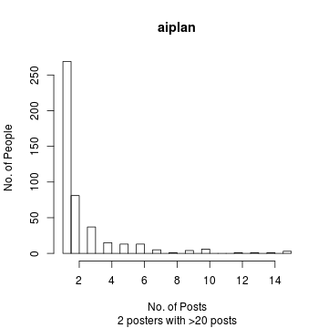

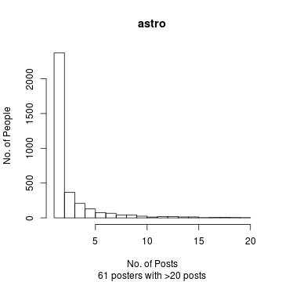

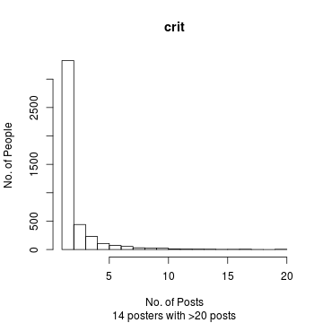

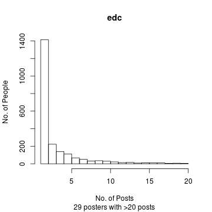

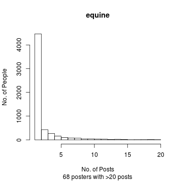

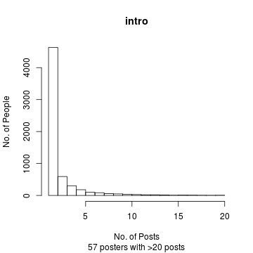

```r
# remove cases where no of posts >20 to simplify plotting
for (i in 1:length(posterDistS)) {
    posterDistSa <- posterDistS[[i]][posterDistS[[i]]$posts <= 20, "posts"]
    cut.posters <- length(posterDistS[[i]]$posts[posterDistS[[i]]$posts > 20])
    hist(posterDistSa, main = names(posterDistS)[i], xlab = "No. of Posts",
        ylab = "No. of People", sub = paste(cut.posters, "posters with >20 posts"),
        breaks = 20)
}
```

I suspect that there are quite a few 1-post people due to a different mechanism - e.g. “introduce yourself” - compared to people who actually used the forums for a purpose. Hence if we wanted to compare distributions between courses we should probably cut 1 (or even 1-2) posters. These should appear (mostly) in 1 forum of thread, so could be eliminated if forum/thread titles inspected. Alt, if mixed in, could estimate % by sampling and manual classification.

### Teaching Staff (access_group_id IN (2,3))

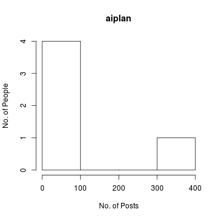

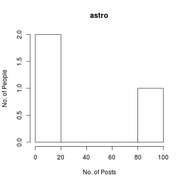

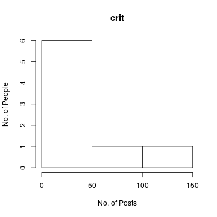

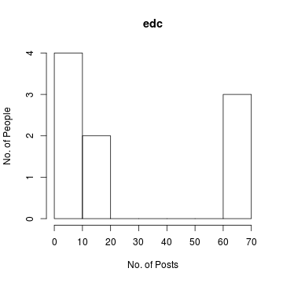

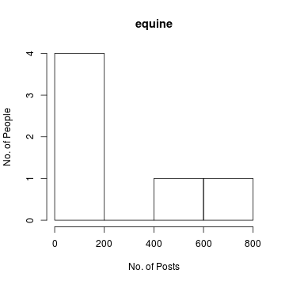

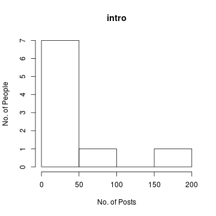

```r
for (i in 1:length(posterDistT)) {
    hist(posterDistT[[i]]$posts, main = names(posterDistT)[i], xlab = "No. of Posts",
        ylab = "No. of People")
}
```

## Distribution of No. of Comments Per Person

What is the distribution of the number of people making 1,2,… comments? Comments on deleted posts *are* counted this time since they probably do represent something meaningful about the students' experience of the course.

*Non-commenters are excluded*

```
## SELECT fc.forum_user_id, COUNT(fc.forum_user_id) comments
##    FROM  vpodata_aiplanfor.forum_comments fc, vpodata_aiplanmap.hash_mapping m, vpodata_aiplangen.users u
##    WHERE fc.forum_user_id = m.forum_user_id AND m.anon_user_id = u.anon_user_id
##         AND fc.deleted=0 AND fc.is_spam=0 AND u.access_group_id =4
##             GROUP BY fc.forum_user_id
```

```
## SELECT fc.forum_user_id, COUNT(fc.forum_user_id) comments
##    FROM  vpodata_aiplanfor.forum_comments fc, vpodata_aiplanmap.hash_mapping m, vpodata_aiplangen.users u
##    WHERE fc.forum_user_id = m.forum_user_id AND m.anon_user_id = u.anon_user_id
##         AND fc.deleted=0 AND fc.is_spam=0 AND u.access_group_id IN (2,3)
##             GROUP BY fc.forum_user_id
```

### Students (access_group_id=4)

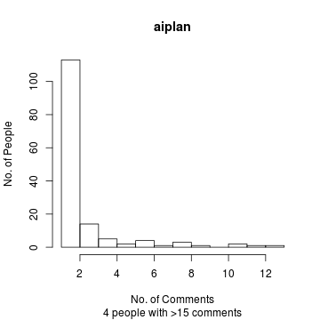

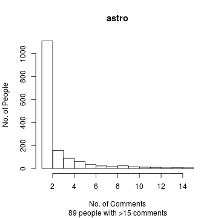

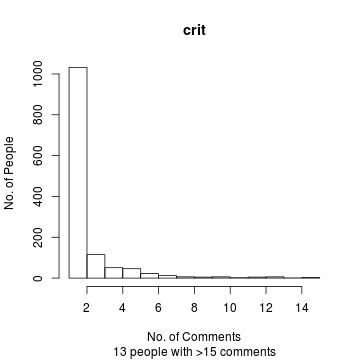

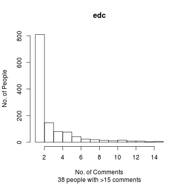

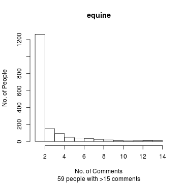

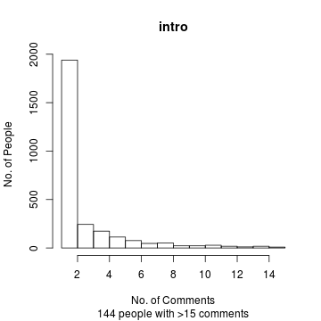

```r
# remove cases where no of posts >20 to simplify plotting
for (i in 1:length(posterDistS)) {
    commenterDistSa <- commenterDistS[[i]][commenterDistS[[i]]$comments <= 15,
        "comments"]
    cut.commenters <- length(commenterDistS[[i]]$comments[commenterDistS[[i]]$comments >
        15])
    hist(commenterDistSa, main = names(commenterDistS)[i], xlab = "No. of Comments",
        ylab = "No. of People", sub = paste(cut.commenters, "people with >15 comments"),
        breaks = 15)
}
```

### Teaching Staff (access_group_id IN (2,3))

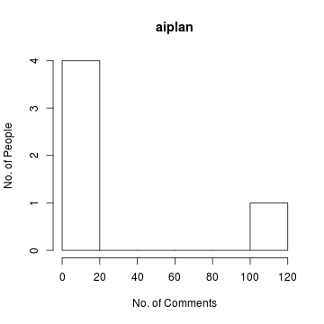

[figure not shown]

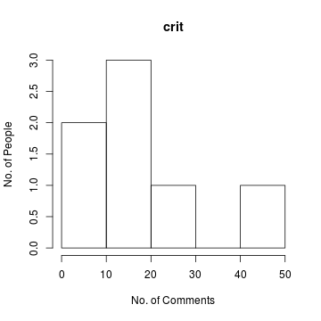

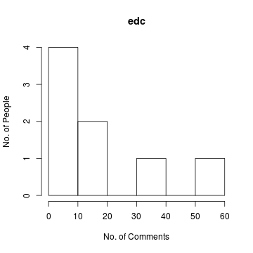

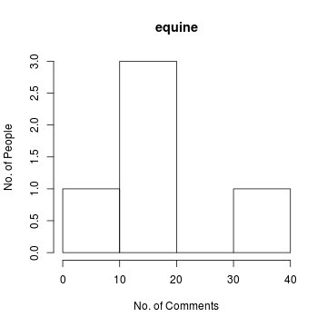

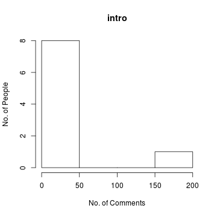

```r
for (i in 1:length(posterDistT)) {
    hist(commenterDistT[[i]]$comments, main = names(commenterDistT)[i], xlab = "No. of Comments",
        ylab = "No. of People")
}
```

## Density comments on posts (etc), compare distributions

### Bushiness Factors

```
## SELECT count(id) forums FROM vpodata_aiplanfor.forum_forums WHERE deleted=0 AND parent_id >=0
```

```
## SELECT count(ft.id) threads FROM  vpodata_aiplanfor.forum_threads ft, vpodata_aiplanfor.forum_forums ff
##    WHERE ft.forum_id = ff.id AND ff.deleted=0 AND ft.deleted=0 AND ft.is_spam=0
```

```
## SELECT count(fp.id) posts
##    FROM vpodata_aiplanfor.forum_posts fp, vpodata_aiplanfor.forum_threads ft, vpodata_aiplanfor.forum_forums ff
##       WHERE  ft.forum_id = ff.id AND fp.thread_id = ft.id
##          AND ff.deleted=0 AND ft.deleted=0 AND ft.is_spam=0 AND fp.deleted=0 AND fp.is_spam=0
```

```
## SELECT count(fc.id) comments
##    FROM vpodata_aiplanfor.forum_comments fc, vpodata_aiplanfor.forum_posts fp, vpodata_aiplanfor.forum_threads ft, vpodata_aiplanfor.forum_forums ff
##       WHERE ft.forum_id = ff.id AND fp.thread_id = ft.id AND fc.post_id = fp.id
##          AND ff.deleted=0 AND ft.deleted=0 AND ft.is_spam=0 AND fp.deleted=0 AND fp.is_spam=0
##          AND fc.deleted=0 AND fc.is_spam=0
```

Compute the degree - i.e. the average number of “child” entities per parent - to which forums, threads, post and comments branch. The root forum (with parent=-1) is not counted. Deleted entities and entities with deleted ancestors are not counted. Note that some course have forums containing forums, and threads in both levels of forum. This relationship between forums is ignored; each forum is counted as “1”.

Excluding deletions makes <10% difference to post and comment bushiness but changes thread bushiness by several tens of % since some course data has a lot of forum deletion.

| id | forums | thread_factor | post_factor | comment_factor |
| --- | --- | --- | --- | --- |
| aiplan | 9 | 44.89 | 4.314 | 0.3632 |
| astro | 17 | 99.06 | 7.392 | 0.6736 |
| crit | 19 | 159.89 | 3.559 | 0.3057 |
| edc | 16 | 89.31 | 6.130 | 0.5797 |
| equine | 21 | 230.24 | 3.852 | 0.3513 |
| intro | 9 | 418.00 | 5.137 | 0.8490 |

### Distribution of Comments on Posts

Comments on deleted posts are not included.

```
## SELECT comments, count(post_id) posts FROM (SELECT fp.id post_id,
##    count(fc.id) comments from vpodata_aiplanfor.forum_posts fp
##       LEFT OUTER JOIN vpodata_aiplanfor.forum_comments fc ON fc.post_id = fp.id  WHERE fp.deleted = 0 GROUP BY fp.id) a
##        GROUP BY comments ORDER BY comments
```

```
## SELECT fp.id post_id, count(fc.id) comments from vpodata_aiplanfor.forum_posts fp,
##     vpodata_aiplanfor.forum_comments fc WHERE fc.post_id = fp.id AND fp.deleted = 0  GROUP BY fp.id
```

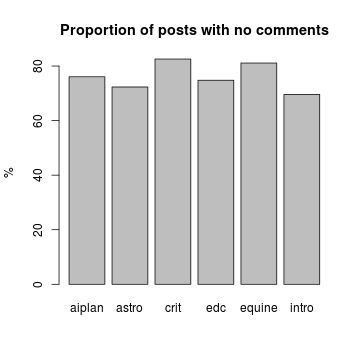

```r
barplot(100 * post_0comments/postCount.df$posts, main = "Proportion of posts with no comments",
    ylab = "%")
```

What is the distribution of the number of posts with 1,2,… comments on them?

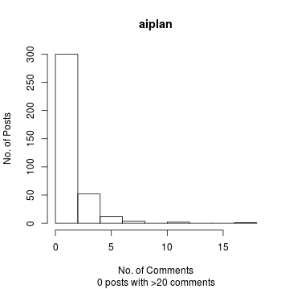

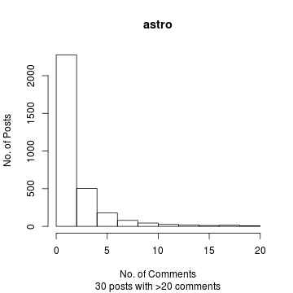

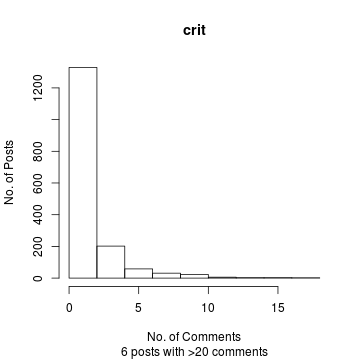

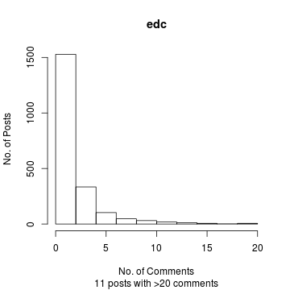

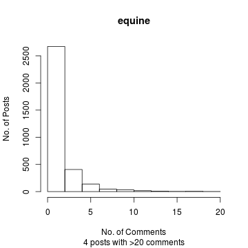

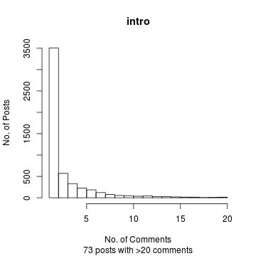

```
## Saved to Basic Forum Stats.RData
```

```
## [1] TRUE
```

```r
# remove cases where comments>20 to simplify plotting
for (i in 1:length(post_commentDist2)) {
    post_commentDist2a <- post_commentDist2[[i]][post_commentDist2[[i]]$comments <=
        20, "comments"]
    cut.posts <- length(post_commentDist2[[i]]$comments[post_commentDist2[[i]]$comments >
        20])
    hist(post_commentDist2a, main = names(post_commentDist2)[i], xlab = "No. of Comments",
        ylab = "No. of Posts", sub = paste(cut.posts, "posts with >20 comments"))
}
```